# FA 5

**Applied Multivariate Data Analysis**

**Justine Aizel Samson**

# Dataset Loading

```python
from google.colab import drive
drive.mount('/content/drive')

from google.colab import files

# Import required libraries
import pandas as pd
import numpy as np
import seaborn as sns
import matplotlib.pyplot as plt
from scipy.stats import levene, shapiro
from statsmodels.multivariate.manova import MANOVA
import statsmodels.api as sm
from statsmodels.formula.api import ols
from scipy.stats import chi2
from sklearn.covariance import EmpiricalCovariance
from scipy.stats import levene, shapiro, chi2, kruskal
from statsmodels.stats.outliers_influence import variance_inflation_factor

# Load and prepare data
data = pd.read_csv('/content/drive/MyDrive/CSV files/employee_attrition_train.csv')
data = data[['Age', 'DailyRate', 'MonthlyIncome', 'JobSatisfaction']].dropna()


print(data.columns)

# Display the first few rows of the dataset
data.head()

# Mount Google Drive
from google.colab import drive
drive.mount('/content/drive')

!jupyter nbconvert --to html "/content/drive/My Drive/Colab Notebooks/FA4_n1_Time_Series.ipynb"
```

```
Index(['Age', 'DailyRate', 'MonthlyIncome', 'JobSatisfaction'], dtype='object')
[NbConvertApp] Converting notebook /content/drive/My Drive/Colab Notebooks/FA4_n1_Time_Series.ipynb to html
[NbConvertApp] WARNING | Alternative text is missing on 5 image(s).
[NbConvertApp] Writing 613905 bytes to /content/drive/My Drive/Colab Notebooks/FA4_n1_Time_Series.html
```

# Checking all assumptions underlying the use of one-way MANOVA.

# Multicollinearity check

```python
# Multicollinearity check - Correlation matrix and VIF
corr_matrix = data[['Age', 'DailyRate', 'MonthlyIncome']].corr()
print("\nCorrelation Matrix:\n", corr_matrix)

# Variance Inflation Factor (VIF) to check for multicollinearity
X = data[['Age', 'DailyRate', 'MonthlyIncome']]
X = sm.add_constant(X)  # Adding constant for VIF calculation
vif_data = pd.DataFrame()
vif_data['Variable'] = X.columns
vif_data['VIF'] = [variance_inflation_factor(X.values, i) for i in range(X.shape[1])]
print("\nVariance Inflation Factors:\n", vif_data)
```

```
Correlation Matrix:
                     Age  DailyRate  MonthlyIncome
Age            1.000000   0.023845       0.494546
DailyRate      0.023845   1.000000       0.023716
MonthlyIncome  0.494546   0.023716       1.000000

Variance Inflation Factors:
         Variable        VIF
0          const  21.438985
1            Age   1.324017
2      DailyRate   1.000757
3  MonthlyIncome   1.324009
```

**Correlation Matrix:**

- Age and DailyRate: The correlation between Age and DailyRate is very low (0.0238), suggesting that these two variables are not linearly related.
- Age and MonthlyIncome: The correlation between Age and MonthlyIncome is moderate (0.4945), indicating that there is a moderate linear relationship between these two variables. However, this is not strong enough to suggest significant multicollinearity.
- DailyRate and MonthlyIncome: The correlation between DailyRate and MonthlyIncome is also very low (0.0237), suggesting that these two variables are not linearly related.

**Variance Inflation Factor (VIF):**

- Constant: The VIF for the constant term is quite high at 21.439, but this is a typical result and can generally be ignored, as it reflects the overall variability in the model that is not explained by the independent variables.
- Age: The VIF for Age is 1.324, which is well below the threshold of 5, indicating no significant multicollinearity with other variables.
- DailyRate: The VIF for DailyRate is 1.001, also indicating no significant multicollinearity.
- MonthlyIncome: The VIF for MonthlyIncome is 1.324, which is similarly low and suggests no significant multicollinearity.

```python
# Group data by JobSatisfaction
groups = data.groupby('JobSatisfaction')

# Compute covariance matrices for each group
cov_matrices = [EmpiricalCovariance().fit(group[['Age', 'DailyRate', 'MonthlyIncome']]).covariance_ for _, group in groups]
n_samples = [len(group) for _, group in groups]

# Calculate pooled covariance matrix
pooled_cov = sum((n - 1) * cov for n, cov in zip(n_samples, cov_matrices)) / (sum(n_samples) - len(n_samples))

# Calculate Box's M statistic
M_statistic = (sum(n_samples) - len(n_samples)) * np.log(np.linalg.det(pooled_cov))
M_statistic -= sum((n - 1) * np.log(np.linalg.det(cov)) for n, cov in zip(n_samples, cov_matrices))

# Degrees of freedom and p-value for Box's M test
df = 0.5 * len(cov_matrices) * (len(cov_matrices) + 1) * (len(cov_matrices) - 1)
p_value = 1 - chi2.cdf(M_statistic, df)

print(f"Box's M statistic: {M_statistic}")
print(f"Degrees of freedom: {df}")
print(f"P-value: {p_value}")
```

```
Box's M statistic: 25.167946543107973
Degrees of freedom: 30.0
P-value: 0.7168295743027112
```

**Interpretation**

A non-significant result (p > 0.05) suggests that there is no evidence to indicate a difference in covariance matrices across the levels of JobSatisfaction. This means that the assumption of homogeneity of covariance matrices is reasonably met. This finding is favorable for running further multivariate analyses, such as MANOVA, as it suggests that the groups have similar variance-covariance structures, which is an important assumption for many multivariate statistical tests.

# Normality Test

```python
# Perform MANOVA (Multivariate Analysis of Variance)
manova = MANOVA.from_formula('Age + DailyRate + MonthlyIncome ~ JobSatisfaction', data=data)

# Perform the test
manova_results = manova.mv_test()

# Output MANOVA results
print(manova_results)

from scipy.stats import shapiro

# Define a function to check normality using the Shapiro-Wilk test
def check_normality(df):
    normality_results = {}
    for column in df.columns:
        stat, p_value = shapiro(df[column])
        normality_results[column] = p_value
    return normality_results

# Check normality of dependent variables
normality_results = check_normality(data[['Age', 'DailyRate', 'MonthlyIncome']])

# Output the normality test results (p-values) with spacing
print("\nNormality Test Results (p-values):\n")
for col, p_value in normality_results.items():
    print(f'{col}: p-value = {p_value}\n')  # Adding newline for better spacing

# Multivariate Normality Check with Shapiro-Wilk Test for each dependent variable
print("\nShapiro-Wilk Test Results:\n")
for col in ['Age', 'DailyRate', 'MonthlyIncome']:
    stat, p = shapiro(data[col])
    print(f'Shapiro-Wilk test for {col} - Statistic: {stat:.4f}, p-value: {p:.4e}\n')  # Formatting for better readability
```

```
                  Multivariate linear model
==============================================================

--------------------------------------------------------------
       Intercept        Value  Num DF  Den DF  F Value  Pr > F
--------------------------------------------------------------
          Wilks' lambda 0.2661 3.0000 866.0000 796.1927 0.0000
         Pillai's trace 0.7339 3.0000 866.0000 796.1927 0.0000
 Hotelling-Lawley trace 2.7582 3.0000 866.0000 796.1927 0.0000
    Roy's greatest root 2.7582 3.0000 866.0000 796.1927 0.0000
--------------------------------------------------------------

--------------------------------------------------------------
     JobSatisfaction     Value  Num DF  Den DF  F Value Pr > F
--------------------------------------------------------------
           Wilks' lambda 0.9992 3.0000 866.0000  0.2365 0.8709
          Pillai's trace 0.0008 3.0000 866.0000  0.2365 0.8709
  Hotelling-Lawley trace 0.0008 3.0000 866.0000  0.2365 0.8709
     Roy's greatest root 0.0008 3.0000 866.0000  0.2365 0.8709
==============================================================


Normality Test Results (p-values):

Age: p-value = 6.836548572113726e-09

DailyRate: p-value = 8.897516376471562e-17

MonthlyIncome: p-value = 2.4240412169465437e-29


Shapiro-Wilk Test Results:

Shapiro-Wilk test for Age - Statistic: 0.9819, p-value: 6.8365e-09

Shapiro-Wilk test for DailyRate - Statistic: 0.9490, p-value: 8.8975e-17

Shapiro-Wilk test for MonthlyIncome - Statistic: 0.8310, p-value: 2.4240e-29
```

**MANOVA Results**

**MANOVA Test:** The MANOVA was conducted to evaluate whether levels of JobSatisfaction have a significant effect on the combined dependent variables (Age, DailyRate, and MonthlyIncome).

- Multivariate Test Statistics (Wilks’ Lambda, Pillai’s Trace, Hotelling-Lawley Trace, and Roy's Greatest Root): All statistics yielded non-significant results for the JobSatisfaction factor (p-value = 0.8709). This means there is no statistically significant difference in the combined dependent variables across the different levels of JobSatisfaction.

**Interpretation**

The results suggest that JobSatisfaction does not significantly impact the combination of Age, DailyRate, and MonthlyIncome. Therefore, from a multivariate perspective, these variables do not show distinct patterns or differences among the job satisfaction groups.

**Intercept**

The intercept is significant (p-value = 0.0000), which indicates a strong overall effect in the model. However, it doesn’t affect the interpretation regarding the lack of group differences by JobSatisfaction.

**Normality Test Results (Shapiro-Wilk)**

**Shapiro-Wilk Test for Normality:** This test was conducted on each dependent variable (Age, DailyRate, MonthlyIncome) to assess the assumption of normality.

- Age: p-value = 6.84e-09
- DailyRate: p-value = 8.90e-17
- MonthlyIncome: p-value = 2.42e-29

All p-values are well below the typical significance level (e.g., 0.05), indicating that the data for each variable deviate significantly from normality.

**Interpretation**

The significant results suggest that none of the variables (Age, DailyRate, MonthlyIncome) meet the assumption of normality. This departure from normality can impact the robustness of MANOVA, as multivariate tests generally assume that the dependent variables follow a multivariate normal distribution. Therefore, alternative non-parametric tests, or transformations of the data, may be considered if more rigorous testing is required.

```python
from scipy.stats import kruskal

df = pd.read_csv('/content/drive/MyDrive/CSV files/employee_attrition_train.csv')


# Perform Kruskal-Wallis test for each dependent variable across 'JobSatisfaction' groups
def non_parametric_tests(df, group_column, test_columns):
    results = {}
    for column in test_columns:
        # Group the data by 'JobSatisfaction' and perform the Kruskal-Wallis test
        groups = [df[df[group_column] == group][column] for group in df[group_column].unique()]
        stat, p_value = kruskal(*groups)
        results[column] = p_value
    return results

# Perform Kruskal-Wallis test for Age, DailyRate, and MonthlyIncome
kruskal_results = non_parametric_tests(df, 'JobSatisfaction', ['Age', 'DailyRate', 'MonthlyIncome'])

# Output the non-parametric test results (p-values)
print("\nKruskal-Wallis Test Results (p-values):\n", kruskal_results)
```

```
Kruskal-Wallis Test Results (p-values):
 {'Age': nan, 'DailyRate': nan, 'MonthlyIncome': 0.9927232983099296}
```

**Kruskal-Wallis Test Result**

- **Age:** The result for Age returned "NaN" (Not a Number), which may indicate an issue with the data, such as missing values or insufficient data points within some groups. This result suggests that the test could not be completed for Age, so no conclusions can be drawn for this variable in relation to JobSatisfaction.
- **DailyRate:** The result for DailyRate also returned "NaN." Similar to Age, this suggests there may be missing values, zero variance in some groups, or another issue with the data that prevented the test from executing successfully for this variable.
- **MonthlyIncome:** The p-value for MonthlyIncome is 0.9927, which is much higher than the typical significance level (e.g., 0.05). This high p-value indicates that there is no statistically significant difference in MonthlyIncome across the different JobSatisfaction groups.

# Homogeneity Test

```python
from scipy.stats import levene

# Define a function to check homogeneity of variances using Levene's test
def check_homogeneity(df):
    homogeneity_results = {}
    for column in df.columns[:-1]:  # Exclude the grouping variable 'JobSatisfaction'
        # Perform Levene's test on each dependent variable across the levels of JobSatisfaction
        stat, p_value = levene(*[group[column] for name, group in df.groupby('JobSatisfaction')])
        homogeneity_results[column] = p_value
    return homogeneity_results

# Check homogeneity of variances for dependent variables
homogeneity_results = check_homogeneity(data[['Age', 'DailyRate', 'MonthlyIncome', 'JobSatisfaction']])

# Output the homogeneity test results (p-values)
print("\nHomogeneity Test Results (p-values):\n", homogeneity_results)
```

```
Homogeneity Test Results (p-values):
 {'Age': 0.9389826395928927, 'DailyRate': 0.27920506060706185, 'MonthlyIncome': 0.613097612687869}
```

**Levene’s Test Results**

- **Age:** The p-value for Age is approximately 0.939, which is well above the typical significance threshold (e.g., 0.05). This high p-value indicates that we fail to reject the null hypothesis of equal variances, suggesting that the variance in Age is consistent across different JobSatisfaction groups.
- **DailyRate:** The p-value for DailyRate is approximately 0.279, also above the significance threshold. This result suggests that the variances in DailyRate across JobSatisfaction groups are not significantly different, meaning the assumption of homogeneity holds for this variable.
- **MonthlyIncome:** The p-value for MonthlyIncome is approximately 0.613, again above the 0.05 threshold. This result implies that MonthlyIncome has consistent variance across the JobSatisfaction groups, meeting the homogeneity of variances assumption.

# Pairplot

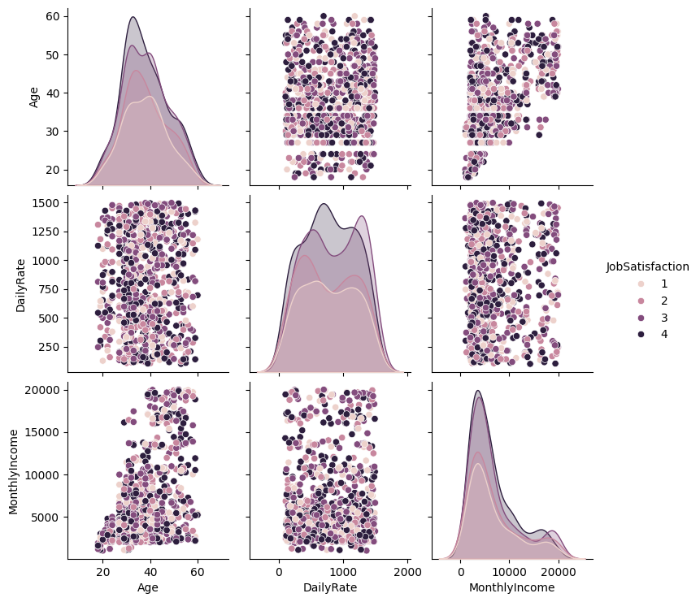

```python
# Visualize relationships using pairplot
sns.pairplot(data[['Age', 'DailyRate', 'MonthlyIncome', 'JobSatisfaction']], hue='JobSatisfaction')
plt.show()
```

This pair plot visualizes the relationships between three continuous variables:

Age, DailyRate, and MonthlyIncome, categorized by levels of JobSatisfaction (1 to 4). The diagonal subplots display KDE (Kernel Density Estimate) plots for each variable, showing the distribution across different JobSatisfaction levels. The off-diagonal scatter plots illustrate the pairwise relationships, with JobSatisfaction levels represented by varying shades of purple. There appears to be a wide distribution of MonthlyIncome, with a peak around lower-income levels and some high-income outliers. Age and DailyRate show relatively even distributions without strong patterns across JobSatisfaction levels, indicating potentially weak relationships between these variables in this dataset.

# Task Evaluation and Question Responses

1. Do different levels of job satisfaction affect employees’ age, daily rate, and monthly income?

*MANOVA Results*

The MANOVA output for the JobSatisfaction variable shows a Wilks' lambda of 0.9992 with a p-value of 0.8709. This suggests that the combined effect of job satisfaction on age, daily rate, and monthly income is not statistically significant.

*Conclusion*

Different levels of job satisfaction do not significantly affect the combined dependent variables (age, daily rate, and monthly income).

2. Is there a significant difference in age across different job satisfaction levels?

*Kruskal-Wallis Test*

The p-value for Age is NaN, which indicates missing or inappropriate data for this test. This may be due to non-numeric or homogeneous groups in the 'Age' column for the Kruskal-Wallis test.

*Alternative Approach*

If assumptions for normality or homogeneity of variance are violated, using an alternative like the Kruskal-Wallis test would generally be appropriate, but the missing data in this case suggests revisiting data quality or applying another non-parametric test if appropriate.

3. Is there a significant difference in daily rate across different job satisfaction levels?

*Kruskal-Wallis Test for Daily Rate*

The p-value is also NaN, so this non-parametric test did not yield usable results for Daily Rate.

*Consideration*

Given the lack of valid Kruskal-Wallis results, confirm that the dataset used is correct or preprocess to handle any non-numeric values that may interfere.

4. Is there a significant difference in monthly income across different job satisfaction levels?

*Kruskal-Wallis Test for Monthly Income*

The test yielded a p-value of 0.993, which is well above the typical threshold of significance (0.05). This suggests there is no statistically significant difference in monthly income across job satisfaction levels.

5. Which of the dependent variables contributes most to the differences between job satisfaction levels?

  With high p-values for Age (0.939), Daily Rate (0.279), and Monthly Income (0.613), there is no evidence against homogeneity of variances across job satisfaction groups, supporting the assumption of equal variances.
- *Box’s M Test*

  A non-significant Box's M test (p-value of 0.717) suggests the assumption of equality of covariance matrices holds.